# RestREco

12 Jul 2024

# Notes to RR12Jul2024 analysis version

This version of analysis aggregates replicas within sites.

Aggregating data is a valid method for designs that include replicas. However, it has its limitations. For instance, it doesn’t account for different variance in aggregation units.

Mixed models (which include random effects) could be an alternative to merging replicas:

https://stats.oarc.ucla.edu/other/mult-pkg/introduction-to-linear-mixed-models/

Of course, mixed models also have limitations:

1. it is difficult to apply mixed models for the multivatiate permutation ANOVA (PERMANOVA) as implemented in adonis2() function - https://github.com/vegandevs/vegan/issues/429
2. there are conceptual issues with assessing significance in mixed models - https://stats.stackexchange.com/questions/22988/how-to-obtain-the-p-value-check-significance-of-an-effect-in-a-lme4-mixed-mode

The mixed models will be evaluated in a separate analysis. Then we will choose between aggregating replicas and applying mixed models.

*In this version of analysis the aggregated counts per sample look very odd!* *Both: before and after normalizing !*

Age of restoration, pH and Conductivity not yet included in analysis.

Variance of the factors between replicas in sites still not explored.

# Introduction

**RestREco** project (PI Prof. Jim Harris) : https://restreco.com/  
The **RestREco** project studies ecosystems recovery after industrial or agricultural use. The main idea behind the project is that we will never be able to restore ecosystems to their prior state (because of the climate change, population increase, the technology developments etcf). So, we need to develop some new criteria to manage ecosystem restoration: for instance restore to some sufficiently **complex** and **resilient** state (so called “**restoration to complexity**”).

Soil microbiome is just one of the many aspects considered by the project. Soil samples were collected from tens of sites in **Scotland** and in **England**, which had been previously exposed to intensive **Industrial** (quarrying) or **Agricultural** use. The dataset selected for this analysis includes only **woodland** (additionally including a small number of ancient woodland sites and woodland re-wilding sites). The soil microbial community was assessed using 16S-amplicon sequencing.

## Dataset summary

The picture illustrates soil sampling for sequencing (microbiome analysis with 16S and ITS amplicons). In addition to the sequencing: age of restoration, pH, conductivity and some other measurements are currently available for each Site (later pH and conductivity may be available for each Plot).

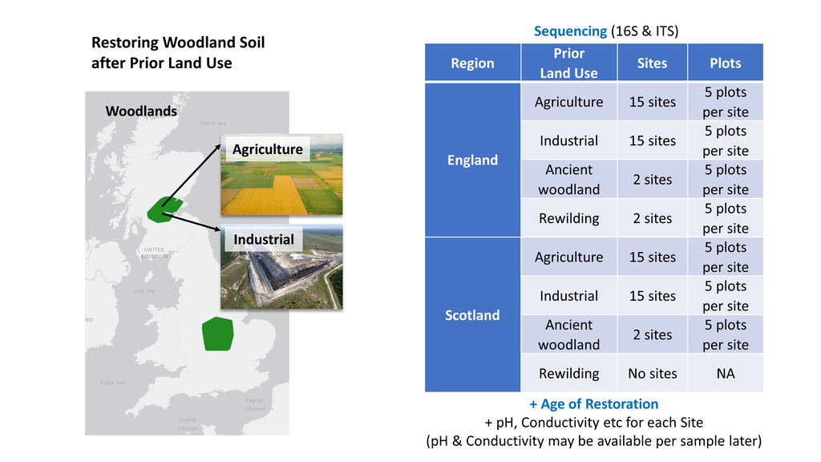

# Prepare environment

## Installing required packages

Installed once, hence the installation commands are commented.  
Some of the packages are not used in this analysis.

```r
# CRAN

# install.packages("vegan")
# install.packages("lme4")
# install.packages("lmerTest")

# Bioconductor

# install.packages("BiocManager")
# BiocManager::install("phyloseq")
# BiocManager::install("ANCOMBC")
# BiocManager::install("mixOmics")

# GitHub

# install.packages("devtools")
# devtools::install_github("jbisanz/qiime2R")
```

## Loading generic packages

The remaining packages will be loaded when needed.

```r
library(dplyr)
library(ggplot2)
```

## Time stamp & initial clean-up

```r
date()
```

```
## [1] "Tue Jul 16 14:09:59 2024"
```

```r
rm(list=ls())
graphics.off()
```

# Import of QIIME2 data

The source data for this analysis was prepared in **QIIME2**. The QIIME2 data format is called “**QIIME2 artifacts**”, and has the **QZA** file extension. We will import **QZA** files to R using **qza_to_phyloseq()** function from **qiime2R** package. The **Phyloseq** object is a commonly used data format for metagenomics data in R. It provides a container for the joint storage of **feature/counts table**, **taxonomy**, **phylogeny** and **samples metadata** (and some other types of data not used in this case).

```r
# Required library
library(qiime2R)

# During knitting setwd() may work for the current chunk only
setwd("C:\\Users\\alexe\\OneDrive - Cranfield University\\Work\\res\\RR\\analysis")

# Source files: assuming files in "data" sub-folder and
# using "\\" for Windows path separator
feature_table_qza <- "data\\feature_table.qza"
rooted_tree_qza <- "data\\rooted_tree.qza"
taxonomy_qza <- "data\\taxonomy.qza"
metadata_tsv <- "data\\samples.txt"

# Read data
data.phy <- qza_to_phyloseq(
    features = feature_table_qza,
    tree = rooted_tree_qza,
    taxonomy = taxonomy_qza,
    metadata = metadata_tsv)

# Cleanup
rm(feature_table_qza, rooted_tree_qza, taxonomy_qza, metadata_tsv)
detach("package:qiime2R", unload=TRUE) # unload qiime2R package
```

# Explore Phyloseq object

## Summary

```r
# Load phyloseq and check its version
library(phyloseq)
packageVersion("phyloseq")
```

```
## [1] '1.46.0'
```

```r
# High-level content of the Phyloseq object
data.phy
```

```
## phyloseq-class experiment-level object
## otu_table()   OTU Table:         [ 60355 taxa and 330 samples ]
## sample_data() Sample Data:       [ 330 samples by 11 sample variables ]
## tax_table()   Taxonomy Table:    [ 60355 taxa by 7 taxonomic ranks ]
## phy_tree()    Phylogenetic Tree: [ 60355 tips and 60236 internal nodes ]
```

## Samples information

```r
dim(sample_data(data.phy))
```

```
## [1] 330  11
```

```r
sample_variables(data.phy)
```

```
##  [1] "Novogene_ID"    "Site_code"      "Site_Code_Plot" "Site_name"      "Plot_no"        "Cranfield_code" "Region"         "Former_landuse" "Woodland_age"   "pH"             "Conductivity"
```

```r
head(sample_names(data.phy))
```

```
## [1] "WP001" "WP002" "WP003" "WP004" "WP005" "WP006"
```

```r
sample_data(data.phy)[1:5,1:5]
```

```
##            Novogene_ID Site_code Site_Code_Plot       Site_name Plot_no
## WP001 FKDN230153473-1A      SW01        SW01_P1 Blackridge_Farm       1
## WP002 FKDN230153474-1A      SW01        SW01_P2 Blackridge_Farm       2
## WP003 FKDN230236203-1A      SW01        SW01_P3 Blackridge_Farm       3
## WP004 FKDN230153476-1A      SW01        SW01_P4 Blackridge_Farm       4
## WP005 FKDN230153477-1A      SW01        SW01_P5 Blackridge_Farm       5
```

```r
# How many sites per Land Use and Region?
table(sample_data(data.phy)[,c("Region","Former_landuse")])
```

```
##           Former_landuse
## Region     Agriculture Ancient_woodland Industrial Rewilding
##   England           75               10         75        10
##   Scotland          75               10         75         0
```

## Feature Table

```r
dim(otu_table(data.phy))
```

```
## [1] 60355   330
```

```r
otu_table(data.phy)[1:10,1:5]
```

```
## OTU Table:          [10 taxa and 5 samples]
##                      taxa are rows
##                                  WP001 WP002 WP003 WP004 WP005
## 90dd28446d3cd23e7707d9d5c2fb4df8     0     0     0     0     0
## 78be05943c92bdd31e9a872ee909279c     0     0     0     0     0
## d6b5940830252894a33e69c8ff9c1a23     0     0     0     0     0
## d037d048afbc9e092d04fa76c860d23d     0     0     0     0     0
## 94456191991e1095be8219ca16e0413e     0     0     0     0     0
## 741481502fb4f4eeba9211d66e4bbda0     0     0     0     0     0
## 8142f3b14a5160a88689c0568dd975dc     0     0     0     0     0
## 16da85f532caa5d7a53f71f09a518c46     0     0     0     0     0
## d7f4617ac1639732ce98499f296f9c08     0     0     0     0     0
## 2b101b9e356663a2581709b5b0981f3e     0     0     0     0     0
```

```r
# Extract to matrix, and check sparsity
otu_table.mx <- as.matrix(otu_table(data.phy))
sum(otu_table.mx==0)/(nrow(otu_table.mx)*ncol(otu_table.mx)) # sparsity: 98%
```

```
## [1] 0.981901
```

```r
# Clean-up
rm(otu_table.mx)
```

## Taxonomy information

```r
# Ranks in the dataset
rank_names(data.phy)
```

```
## [1] "Kingdom" "Phylum"  "Class"   "Order"   "Family"  "Genus"   "Species"
```

```r
# Taxonomy table
dim(tax_table(data.phy))
```

```
## [1] 60355     7
```

```r
tax_table(data.phy)[1:10,]
```

```
## Taxonomy Table:     [10 taxa by 7 taxonomic ranks]:
##                                  Kingdom       Phylum            Class                 Order                  Family                     Genus            Species
## 90dd28446d3cd23e7707d9d5c2fb4df8 "d__Bacteria" "Patescibacteria" "Paceibacteria"       "Paceibacterales"      "Staskawiczbacteraceae"    "GWA2-37-10"     NA
## 78be05943c92bdd31e9a872ee909279c "Unassigned"  NA                NA                    NA                     NA                         NA               NA
## d6b5940830252894a33e69c8ff9c1a23 "d__Bacteria" "Patescibacteria" NA                    NA                     NA                         NA               NA
## d037d048afbc9e092d04fa76c860d23d "d__Bacteria" "Patescibacteria" NA                    NA                     NA                         NA               NA
## 94456191991e1095be8219ca16e0413e "d__Bacteria" "Patescibacteria" NA                    NA                     NA                         NA               NA
## 741481502fb4f4eeba9211d66e4bbda0 "d__Bacteria" "Patescibacteria" NA                    NA                     NA                         NA               NA
## 8142f3b14a5160a88689c0568dd975dc "d__Bacteria" NA                NA                    NA                     NA                         NA               NA
## 16da85f532caa5d7a53f71f09a518c46 "d__Bacteria" "Patescibacteria" NA                    NA                     NA                         NA               NA
## d7f4617ac1639732ce98499f296f9c08 "d__Bacteria" "Proteobacteria"  "Alphaproteobacteria" "Rhizobiales_A_504705" "Xanthobacteraceae_503485" "Bradyrhizobium" NA
## 2b101b9e356663a2581709b5b0981f3e "Unassigned"  NA                NA                    NA                     NA                         NA               NA
```

```r
# Extract to data frame
taxa.df <- as.data.frame(tax_table(data.phy))

# What Kingdoms we have in the dataset (plain R)
table(taxa.df$Kingdom)
```

```
##
##  d__Archaea d__Bacteria  Unassigned
##         161       60173          21
```

```r
# Number of different Phyla in the dataset (dplyr)
n_distinct(taxa.df$Phylum)
```

```
## [1] 67
```

```r
# 7 most abundant Bacterial Phyla (dplyr)
taxa.df %>%
  filter(Kingdom == "d__Bacteria") %>%
  count(Phylum, sort=T) %>%
  head(7)
```

```
##             Phylum     n
## 1   Proteobacteria 12460
## 2  Planctomycetota  9108
## 3 Actinobacteriota  6492
## 4  Acidobacteriota  5815
## 5             <NA>  5250
## 6    Chloroflexota  3550
## 7     Bacteroidota  3296
```

```r
# Clean-up
rm(taxa.df)
```

# Pre-processing

Note that in Phyloseq **Merging/ Agglomerating** is not the same as **Filtering/ Sub-setting/ Pruning**.

## Exclude ancient woodland and rewilding sites

Done for simplicity in this toy example.  
These sites might be kept in the final analysis.

```r
# Summary of the initial data (reminder)
data.phy
```

```
## phyloseq-class experiment-level object
## otu_table()   OTU Table:         [ 60355 taxa and 330 samples ]
## sample_data() Sample Data:       [ 330 samples by 11 sample variables ]
## tax_table()   Taxonomy Table:    [ 60355 taxa by 7 taxonomic ranks ]
## phy_tree()    Phylogenetic Tree: [ 60355 tips and 60236 internal nodes ]
```

```r
# Keep only samples with Industrial or Agricultural prior use
table(sample_data(data.phy)$Former_landuse)
```

```
##
##      Agriculture Ancient_woodland       Industrial        Rewilding
##              150               20              150               10
```

```r
IndAgri.phy <- subset_samples(data.phy,
                              Former_landuse %in% c("Industrial","Agriculture"))

# Summary of the filtered data
IndAgri.phy # Number of samples dropped from 330 to 300
```

```
## phyloseq-class experiment-level object
## otu_table()   OTU Table:         [ 60355 taxa and 300 samples ]
## sample_data() Sample Data:       [ 300 samples by 11 sample variables ]
## tax_table()   Taxonomy Table:    [ 60355 taxa by 7 taxonomic ranks ]
## phy_tree()    Phylogenetic Tree: [ 60355 tips and 60236 internal nodes ]
```

```r
# Clean-up
rm(data.phy)
```

## Exclude SW17 site

SW17 site doesn’t have data in pH and conductivity.  
Excluded for simplicity in this toy example.  
There should be no missed sample metadata after this.  
In the final analysis we may consider another way to handle missed data.

```r
# Summary of the initial data (reminder)
IndAgri.phy
```

```
## phyloseq-class experiment-level object
## otu_table()   OTU Table:         [ 60355 taxa and 300 samples ]
## sample_data() Sample Data:       [ 300 samples by 11 sample variables ]
## tax_table()   Taxonomy Table:    [ 60355 taxa by 7 taxonomic ranks ]
## phy_tree()    Phylogenetic Tree: [ 60355 tips and 60236 internal nodes ]
```

```r
# Keep only samples with Industrial or Agricultural prior use
table(sample_data(IndAgri.phy)$pH)
```

```
##
## 3.78 4.14 4.68  4.7 4.85 4.86 4.88 4.94 4.96 5.01 5.04 5.06 5.16 5.18 5.23 5.25 5.27 5.28 5.31 5.33 5.38 5.41 5.43  5.5 5.54 5.55 5.58 5.62 5.68 5.79 5.81 5.82 5.91 5.92 6.03 6.12 6.23 6.25 6.32 6.41 6.46 6.52 6.82 7.45 7.79  7.8 7.87 7.91 7.93 7.98  N/A
##    5    5    5    5    5   15    5    5    5   10    5    5    5    5    5    5    5    5    5   10    5    5    5    5   10    5    5    5    5    5   10    5    5    5   15    5    5   10    5    5    5    5    5    5    5    5    5    5    5    5    5
```

```r
table(sample_data(IndAgri.phy)$Conductivity)
```

```
##
## 10.32 106.2 106.3 124.4   134 134.5 14.64 141.8   145 148.7 157.9   158 172.4 172.5 174.9 191.3   208  21.2   213   237  25.1  27.2  32.3   320    33  33.1  33.4  34.5  35.2    37    39  39.9  41.6  41.7  44.8  45.4  46.2  46.5  48.2  53.7  55.3  55.4  55.9  57.4  63.7    64  70.7    75  78.8  79…
##     5     5     5     5     5     5     5     5     5     5     5     5     5     5     5     5     5     5     5     5     5     5     5     5     5     5     5     5    10     5     5     5     5     5     5     5     5     5     5     5     5     5     5     5     5     5     5     5     5    …
```

```r
IndAgriNoNA.phy <- subset_samples(IndAgri.phy,
                              Site_code != "SW17")
table(sample_data(IndAgriNoNA.phy)$pH)
```

```
##
## 3.78 4.14 4.68  4.7 4.85 4.86 4.88 4.94 4.96 5.01 5.04 5.06 5.16 5.18 5.23 5.25 5.27 5.28 5.31 5.33 5.38 5.41 5.43  5.5 5.54 5.55 5.58 5.62 5.68 5.79 5.81 5.82 5.91 5.92 6.03 6.12 6.23 6.25 6.32 6.41 6.46 6.52 6.82 7.45 7.79  7.8 7.87 7.91 7.93 7.98
##    5    5    5    5    5   15    5    5    5   10    5    5    5    5    5    5    5    5    5   10    5    5    5    5   10    5    5    5    5    5   10    5    5    5   15    5    5   10    5    5    5    5    5    5    5    5    5    5    5    5
```

```r
table(sample_data(IndAgriNoNA.phy)$Conductivity)
```

```
##
## 10.32 106.2 106.3 124.4   134 134.5 14.64 141.8   145 148.7 157.9   158 172.4 172.5 174.9 191.3   208  21.2   213   237  25.1  27.2  32.3   320    33  33.1  33.4  34.5  35.2    37    39  39.9  41.6  41.7  44.8  45.4  46.2  46.5  48.2  53.7  55.3  55.4  55.9  57.4  63.7    64  70.7    75  78.8  79…
##     5     5     5     5     5     5     5     5     5     5     5     5     5     5     5     5     5     5     5     5     5     5     5     5     5     5     5     5    10     5     5     5     5     5     5     5     5     5     5     5     5     5     5     5     5     5     5     5     5    …
```

```r
# Summary of the filtered data
IndAgriNoNA.phy # Number of samples dropped from 300 to 295
```

```
## phyloseq-class experiment-level object
## otu_table()   OTU Table:         [ 60355 taxa and 295 samples ]
## sample_data() Sample Data:       [ 295 samples by 11 sample variables ]
## tax_table()   Taxonomy Table:    [ 60355 taxa by 7 taxonomic ranks ]
## phy_tree()    Phylogenetic Tree: [ 60355 tips and 60236 internal nodes ]
```

```r
# Clean-up
rm(IndAgri.phy)
```

## Merge replicas within Sites

*phyloseq::merge_samples()* function can be used for aggregating metagenomic data per samples. It aggregates otu_table counts by **sum** and sample_data by **mean**. The taxa table is not changed.

However, the mean function is well defined for numeric data types only. The other data types could be lost in *sample_data* after using *phyloseq::merge_samples()*: https://stackoverflow.com/questions/74287436/sam-data-gets-transformed-into-nas-and-numerical-values-when-using-merge-samples So, the *sample_data* for the merged phyloseq object is prepared manually.

### Prepare samples data

```r
# Extract relevant columns
sample_data.df <- sample_data(IndAgriNoNA.phy)[,c("Site_code","Site_name","Region","Former_landuse","Woodland_age","pH","Conductivity")]

head(sample_data.df)
```

```
##       Site_code       Site_name   Region Former_landuse Woodland_age   pH Conductivity
## WP001      SW01 Blackridge_Farm Scotland    Agriculture           18 5.04         63.7
## WP002      SW01 Blackridge_Farm Scotland    Agriculture           18 5.04         63.7
## WP003      SW01 Blackridge_Farm Scotland    Agriculture           18 5.04         63.7
## WP004      SW01 Blackridge_Farm Scotland    Agriculture           18 5.04         63.7
## WP005      SW01 Blackridge_Farm Scotland    Agriculture           18 5.04         63.7
## WP006      SW02       Cassafuir Scotland    Agriculture           50 4.85         33.4
```

```r
str(sample_data.df)
```

```
## 'data.frame':    295 obs. of  7 variables:
## Formal class 'sample_data' [package "phyloseq"] with 4 slots
##   ..@ .Data    :List of 7
##   .. ..$ : chr  "SW01" "SW01" "SW01" "SW01" ...
##   .. ..$ : chr  "Blackridge_Farm" "Blackridge_Farm" "Blackridge_Farm" "Blackridge_Farm" ...
##   .. ..$ : chr  "Scotland" "Scotland" "Scotland" "Scotland" ...
##   .. ..$ : chr  "Agriculture" "Agriculture" "Agriculture" "Agriculture" ...
##   .. ..$ : int  18 18 18 18 18 50 50 50 50 50 ...
##   .. ..$ : chr  "5.04" "5.04" "5.04" "5.04" ...
##   .. ..$ : chr  "63.7" "63.7" "63.7" "63.7" ...
##   ..@ names    : chr  "Site_code" "Site_name" "Region" "Former_landuse" ...
##   ..@ row.names: chr  "WP001" "WP002" "WP003" "WP004" ...
##   ..@ .S3Class : chr "data.frame"
```

```r
# Update the data types (just in case)
sample_data.df$Site_code <- as.factor(sample_data.df$Site_code)
sample_data.df$Site_name <- as.factor(sample_data.df$Site_name)
sample_data.df$Region <- as.factor(sample_data.df$Region)
sample_data.df$Former_landuse <- as.factor(sample_data.df$Former_landuse)
sample_data.df$pH <- as.numeric(sample_data.df$pH)
sample_data.df$Conductivity <- as.numeric(sample_data.df$Conductivity)

# Update the sample_data in phyloseq cobject (just in case)
sample_data.df -> sample_data(IndAgriNoNA.phy)

# Prepare sample_data for phyloseq object after merging
merged_sample_data.df <- sample_data.df %>%
  group_by(Site_code) %>%
  summarise(Site_code = first(Site_code),
            Site_name = first(Site_name),
            Region = first(Region),
            Former_landuse = first(Former_landuse),
            Woodland_age = first(Woodland_age),
            pH = first(pH),
            Conductivity = first(Conductivity))

merged_sample_data.df <- data.frame(merged_sample_data.df)
head(merged_sample_data.df)
```

```
##   Site_code                     Site_name  Region Former_landuse Woodland_age   pH Conductivity
## 1      EW01                 Pick_Triangle England    Agriculture           14 4.86         88.2
## 2      EW02             Bawdon_Lodge_Farm England    Agriculture           17 4.70         64.0
## 3      EW03             George_Henry_Wood England    Agriculture           13 7.87        158.0
## 4      EW04                    Coton_Wood England    Agriculture           27 5.01         75.0
## 5      EW05 King's_Cliffe_Millennium_Wood England    Agriculture           22 7.91        145.0
## 6      EW06                   Nether_Hall England    Agriculture           23 5.25         93.0
```

```r
str(merged_sample_data.df)
```

```
## 'data.frame':    59 obs. of  7 variables:
##  $ Site_code     : Factor w/ 59 levels "EW01","EW02",..: 1 2 3 4 5 6 7 8 9 10 ...
##  $ Site_name     : Factor w/ 59 levels "Addiewell","Auchenberg_House",..: 49 6 26 16 37 47 55 21 22 29 ...
##  $ Region        : Factor w/ 2 levels "England","Scotland": 1 1 1 1 1 1 1 1 1 1 ...
##  $ Former_landuse: Factor w/ 2 levels "Agriculture",..: 1 1 1 1 1 1 1 1 1 1 ...
##  $ Woodland_age  : int  14 17 13 27 22 23 30 27 39 47 ...
##  $ pH            : num  4.86 4.7 7.87 5.01 7.91 5.25 5.33 6.03 5.92 5.58 ...
##  $ Conductivity  : num  88.2 64 158 75 145 ...
```

```r
rownames(merged_sample_data.df) <- merged_sample_data.df$Site_code

# Clean-up
rm(sample_data.df)
```

### Merge phyloseq object

```r
# Select sites, samples and OTUs for exploring
sample_data(IndAgriNoNA.phy)[11:20,"Site_code"]
```

```
##       Site_code
## WP011      SW03
## WP012      SW03
## WP013      SW03
## WP014      SW03
## WP015      SW03
## WP016      SW04
## WP017      SW04
## WP018      SW04
## WP019      SW04
## WP020      SW04
```

```r
sample_ids <- c("WP011","WP012","WP013","WP014","WP015",
                "WP016","WP017","WP018","WP019","WP020")
site_ids <- c("SW03","SW04")

otu_ids <- c("23dcfa0920c4a564f143c6664347f324",
             "33708c0cdfbafeefcde0151d31252aec",
             "6e2fe76ce6d4a17f9ab4bd170bf10949",
             "f04f39df5f5d4fb15a3d132d05b651ab",
             "2c693916f6f3ff9538dfbf075ad9f669")

# Look at the selected data before merging
otu_table(IndAgriNoNA.phy)[otu_ids,sample_ids]
```

```
## OTU Table:          [5 taxa and 10 samples]
##                      taxa are rows
##                                  WP011 WP012 WP013 WP014 WP015 WP016 WP017 WP018 WP019 WP020
## 23dcfa0920c4a564f143c6664347f324    29     0    19     0     0     0     0    18    17     0
## 33708c0cdfbafeefcde0151d31252aec    25    18    19    23    31     0     0     0     0     0
## 6e2fe76ce6d4a17f9ab4bd170bf10949     0    10     0     0     0     0     0     0     0     0
## f04f39df5f5d4fb15a3d132d05b651ab     0     0     0     4     0     0     0     0     0     0
## 2c693916f6f3ff9538dfbf075ad9f669     0     0     0     6     0     0     0     0     8     0
```

```r
# Merge phyloseq object
IndAgriSite.phy <- merge_samples(IndAgriNoNA.phy, "Site_code")

IndAgriSite.phy
```

```
## phyloseq-class experiment-level object
## otu_table()   OTU Table:         [ 60355 taxa and 59 samples ]
## sample_data() Sample Data:       [ 59 samples by 7 sample variables ]
## tax_table()   Taxonomy Table:    [ 60355 taxa by 7 taxonomic ranks ]
## phy_tree()    Phylogenetic Tree: [ 60355 tips and 60236 internal nodes ]
```

```r
# Look at the selected OTU counts after merging:
# - The OTU table has been transposed
# - The OTU merging uses sum() not mean()
t(otu_table(IndAgriSite.phy)[site_ids,otu_ids])
```

```
## OTU Table:          [5 taxa and 2 samples]
##                      taxa are rows
##                                  SW03 SW04
## 23dcfa0920c4a564f143c6664347f324   48   35
## 33708c0cdfbafeefcde0151d31252aec  116    0
## 6e2fe76ce6d4a17f9ab4bd170bf10949   10    0
## f04f39df5f5d4fb15a3d132d05b651ab    4    0
## 2c693916f6f3ff9538dfbf075ad9f669    6    8
```

```r
# Explore metadata:
# the names for categorical variables lost
head(sample_data(IndAgriSite.phy))
```

```
##      Site_code Site_name Region Former_landuse Woodland_age   pH Conductivity
## EW01         1        49      1              1           14 4.86         88.2
## EW02         2         6      1              1           17 4.70         64.0
## EW03         3        26      1              1           13 7.87        158.0
## EW04         4        16      1              1           27 5.01         75.0
## EW05         5        37      1              1           22 7.91        145.0
## EW06         6        47      1              1           23 5.25         93.0
```

```r
# Clean-up
rm(IndAgriNoNA.phy,otu_ids,sample_ids,site_ids)
```

### Update the sample_data

```r
# Check that the sites are in the same order
all(rownames(merged_sample_data.df) == rownames(sample_data(IndAgriSite.phy)))
```

```
## [1] TRUE
```

```r
# Put new sample_data to the merged phyloseq object
merged_sample_data.df -> sample_data(IndAgriSite.phy)

# Check results
head(sample_data(IndAgriSite.phy))
```

```
##      Site_code                     Site_name  Region Former_landuse Woodland_age   pH Conductivity
## EW01      EW01                 Pick_Triangle England    Agriculture           14 4.86         88.2
## EW02      EW02             Bawdon_Lodge_Farm England    Agriculture           17 4.70         64.0
## EW03      EW03             George_Henry_Wood England    Agriculture           13 7.87        158.0
## EW04      EW04                    Coton_Wood England    Agriculture           27 5.01         75.0
## EW05      EW05 King's_Cliffe_Millennium_Wood England    Agriculture           22 7.91        145.0
## EW06      EW06                   Nether_Hall England    Agriculture           23 5.25         93.0
```

```r
# Clean-up
rm(merged_sample_data.df)
```